# Exercise of Random Variables

Kuei Yueh Ko

2017/3/2

1. Random Numbers Generation
   - 1. Generate 10000 random numbers from Gaussian distribution with mean=20 and variance =10, and plot the distribution.
   - 2. Generate 10000 random numbers from Binomial distribution with p=0.5 and n=40, and plot the distribution.
   - 3. Compare the distribution of 1a and 1b, what do you find?
2. Make a program that can select our candidates for presentation next week. This program should select randomly but avoid selecting the numbers that had been selected before.
   - (hint: uniform distribution, loop, and if statements.)

# Prepare the function

create my functions for each random variable generator

```r
# Gaussian Distribution
myGauss <- function(n, mu, sigma2){
    x <- rnorm(n)
    y <- x * (sigma2^0.5) + mu
    return(y)
} # end function myGauss

# Shifting a Gaussian Distribution into desire mu and variance
ShiftDistr <- function(x, mu, sigma2){
    # first transform the distribution into standard norm
    z <- x / sd(x) - mean(x)
    # then shift the distribution into desire one
    y <- z * (sigma2^0.5) + mu
    return(y)
} # end function myGaussShift

# Uniform Distribution [0,1]
myUnif <- function(n, a=0, b=1) {
    x <- runif(n)
    y <- x * (b-a) + a
    return(y)
} # end func myUnif

# Bernoulli Distribution
myBern  <- function(n, prob=0.5){
    res <- ifelse(runif(n) <= prob, 1, 0)
    return(res)
} # end func myBern

# Binomial Distribution
myBinom <- function(n, size, prob=0.5){
    # Generate random numbers from binomial distribution
    # which is the sum of bernoulli random variable
    res <- replicate(n, sum(myBern(size, prob)))
    return(res)
} # end func myBinom
```

Helper function to plot matrix

```r
plotMatrix <- function(dat, isXlab=T, isYlab=T){
    # given a data (matrix or dataframe), plot the
    # value of each element as color
    # ---------------------------------
    # Set color scale
    colPalette.WR <- colorRampPalette(c(
        "#fef0d9", "#fdbb84", "#fc8d59", "#e34a33"))(256)

    # Flipping the matrix
    mat <- as.matrix(dat)
    mat <- t(mat)
    mat <- mat[,ncol(mat):1,drop=FALSE]

    # Plot the matrix
    image(mat, xaxt= "n", yaxt= "n",
          col = colPalette.WR)

    # Show ticks if needed
    if(isXlab){ # if X ticks are added
        axis(1, at=seq(0,1,length.out=ncol(dat)),
             labels=colnames(dat), las=1)
    } # end if
    if(isYlab){ # if Y ticks are added
        axis(2, at=seq(0,1,length.out=nrow(dat)),
             labels=rev(rownames(dat)), las=2)
    } # end if
} # end func plotMatrix
```

# 1a Generate 10000 random numbers from Gaussian distribution with mean=20 and variance=10, and plot the distribution

Here I generated standard normal distribution and transform it into a normal distribution equal mean=20, variance equal to 10

```r
# Decide the number of random numbers
N <- 10000

# Generate standard normal distribution
x <- myGauss(N, 0, 1)

# Shift the distribution into mean=20, variance=10
y <- ShiftDistr(x, 20, 10)
```

visualize the distribution of random numbers before and after transformation

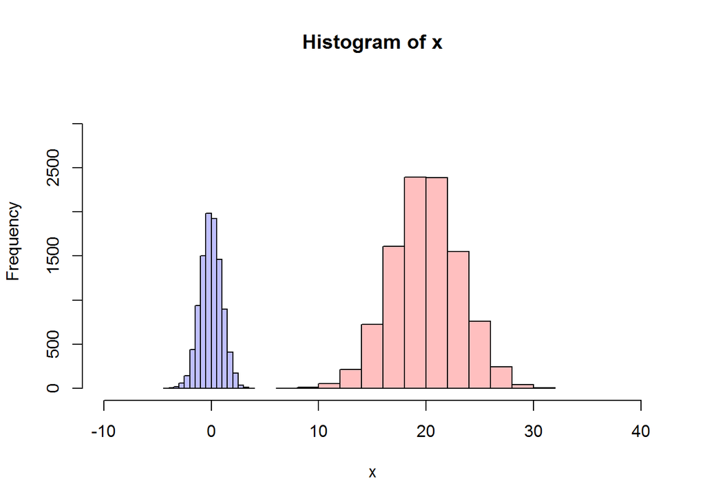

```r
# generate the histogram
gp1 <- hist(x, plot=FALSE)
gp2 <- hist(y, plot=FALSE)

# visualize both histogram in one plot
plot(gp1, col=rgb(0,0,1,1/4),
     xlim=c(-10, 40),
     ylim=c(  0, N/3))
plot(gp2, col=rgb(1,0,0,1/4), add=T)
```

# 1b. Generate 10000 random numbers from Binomial distribution with p=0.5 and n=40, and plot the distribution.

Generate random numbers from binomial distribution, which is the sum of bernoulli random variable (the process of summing bernoulli random variable is implemented in the function myBinom)

```r
# Decide the number of random numbers
N <- 10000

# Generate random numbers from binomial distribution
x <- myBinom(N, 40)
```

Visualize the distribution of random numbers generated

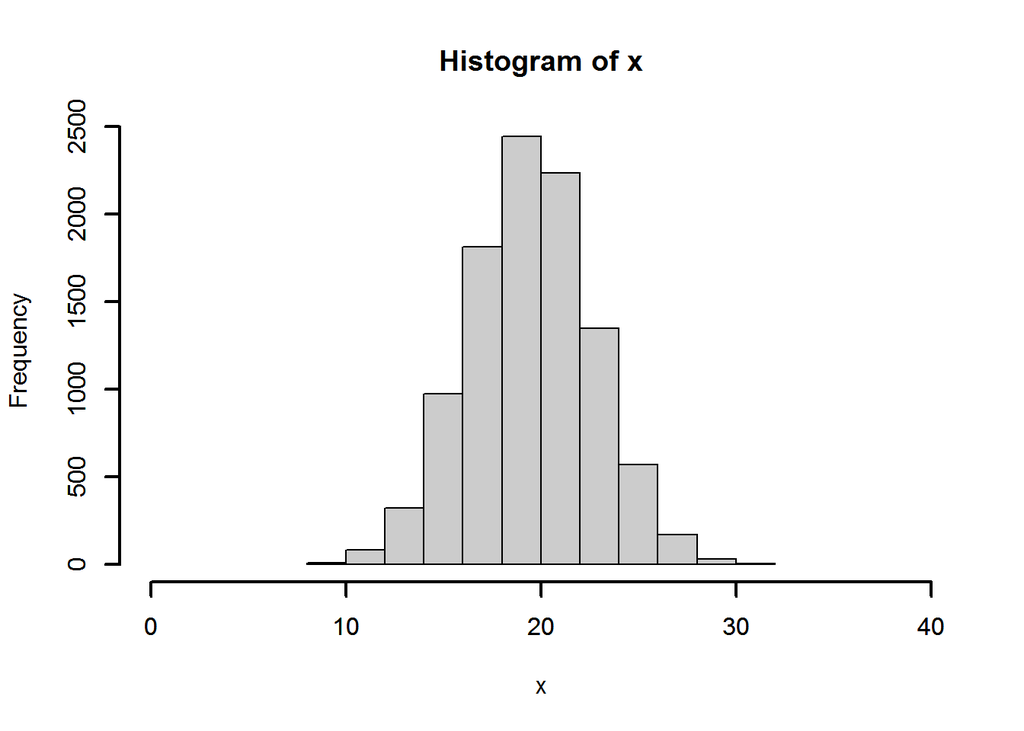

```r
hist(x, col="grey80", xlim=c(0, 40))
axis(side=1, lwd = 2)
axis(side=2, lwd = 2)
```

# 1c. Compare the distribution of 1a and 1b, what do you find?

Theoretically, we know that as we increase the number of random number generated, the distribution of binomial distribution would be similar to normal distribution.

```r
# increase N
N     <- c(10, 50, 100, 1000)
Nchar <- as.character(N)

# intiate list to store random numbers
listBinom <- list()
listGauss <- list()

# generate binomial and Gaussian random numbers with different N
for (idx in 1:length(N)){
    # Binomial distribution
    listBinom[[Nchar[idx]]] <-
        myBinom(N[idx], size=40, prob=0.5)
    # Gaussian distribution
    listGauss[[Nchar[idx]]] <-
        myGauss(N[idx], mean(x), var(x))
} # end for loop
```

Visualize and compare the distribution of Binomial and Gaussian under different N

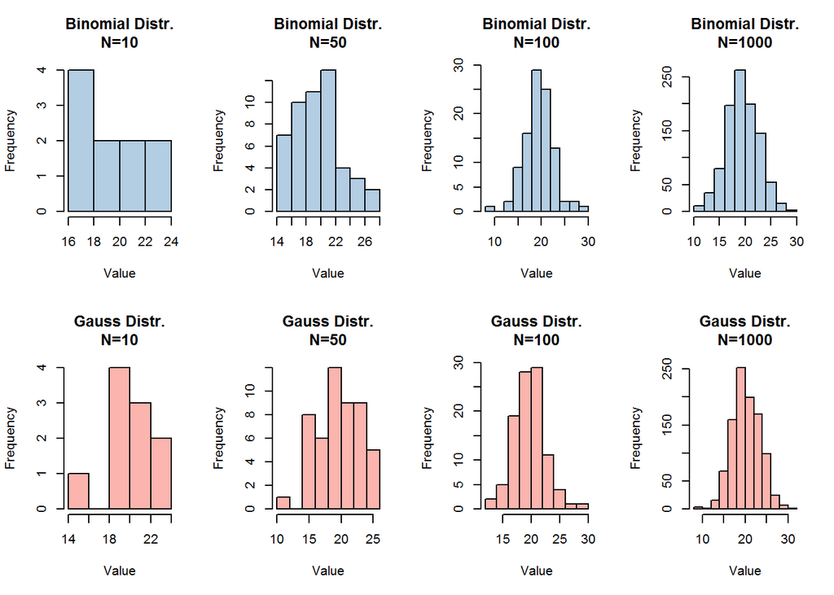

```r
# set plot
par(mfrow=c(2,4))

# plot binomial distribution
for (idx in Nchar){
    hist(listBinom[[idx]],
        col = "#b3cde3",
        main=paste0("Binomial Distr.\nN=", idx),
        xlab = "Value")
} # end for loop

# plot Gaussian distribution
for (idx in Nchar){
    hist(listGauss[[idx]],
        col = "#fbb4ae",
        main=paste0("Gauss Distr.\nN=", idx),
        xlab = "Value")
} # end for loop
```

# 2. Make a program that can select our candidates for presentation next week. This program should select randomly but avoid selecting the numbers that had been selected before. (hint: uniform distribution, loop, and if statements.)

create a function to pick two numbers

```r
Get2NumRand <- function(ids){
    # pick a student using uniform distribution
    idx <- myUnif(1, 0, length(ids))
    idx <- ceiling(idx)
    id01 <- ids[idx]

    # remove the first chosen student
    ids <- setdiff(ids, id01)

    # pick another student from the remain students
    idx <- myUnif(1, 0, length(ids))
    idx <- ceiling(idx)
    id02 <- ids[idx]

    # return result
    return(c(id01, id02))
} # end func
```

Simulate the experiment of choosing two students

```r
# number of simulation
N   <- 100000 # 100,000

# suppose we have 18 students
ids <- 1:18

# simulation
res <- replicate(N, Get2NumRand(ids))
```

Convert the result into a matrix by counting each pair of students

```r
# initiate a matrix to store the result
mat <- matrix(0, nrow=length(ids), ncol=length(ids))

# convert the result into a matrix
for (idx in 1:N){
    mat[res[1,idx], res[2,idx]] <-
        mat[res[1,idx], res[2,idx]] + 1
} # end for loop
```

Visualize the result

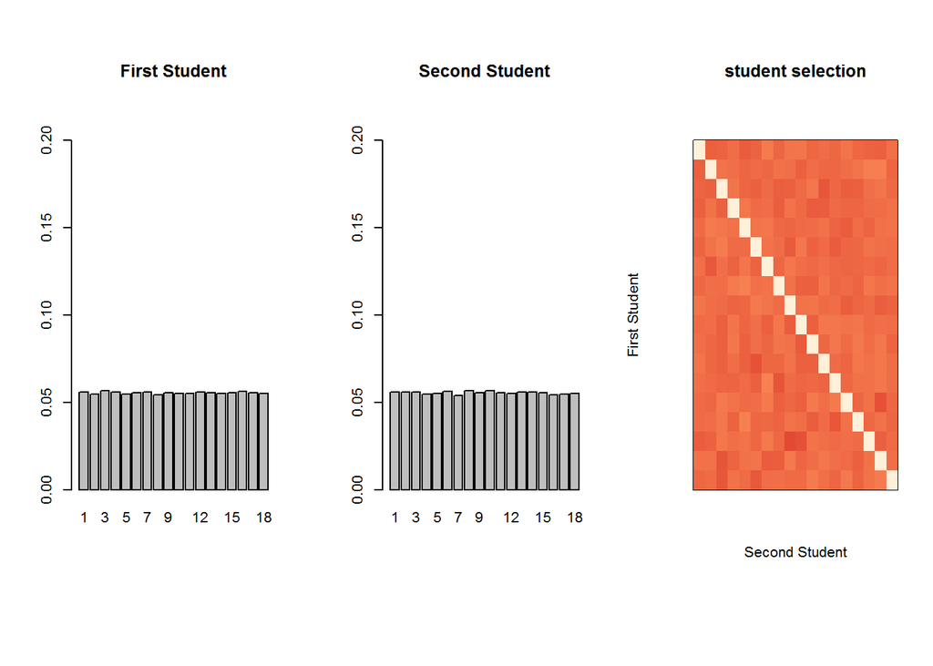

```r
par(mfrow=c(1,3),
    #mar=c(5.1,4.1,4.1,2.1))
    mar=c(10,4.1,8,2))

# plot the frequencies of first student
barplot(table(res[1,]) / N,
        main="First Student",
        ylim=c(0,0.2))

# plot the frequencies of second student
barplot(table(res[2,]) / N,
        main="Second Student",
        ylim=c(0,0.2))

# plot the counting result
plotMatrix(mat, isXlab = F, isYlab = F)
title(
    main="student selection",
    xlab="Second Student",
    ylab="First Student")
```